# Domáca úloha 1

- Platia [všeobecné pokyny](https://anna-hlubinova.github.io/mEMM_DU/)
- **Deadline: 13.10.2024, 23:59:59**
- Rezervácia dát pre oba príklady prebieha v tabuľke https://bit.ly/3zcqIAf v hárku DÚ 1.

## Príklad 1: Výnosy akcií (5 bodov)

Tak ako na cvičení, pomocou knižnice `quantmod` načítajte priamo do R-ka ceny akcií a zistite, či sa ich výnosy dajú modelovať ako biely šum.

Zvoľte si firmu (každý, resp. každá skupina inú) a stiahnite si ceny akcií tejto firmy za zvolené obdobie, minimálne za jeden rok. Pracujte s posledným stĺpcom `Adjusted`. Funkciou `to.weekly` najprv transformujte dáta na týždenné a následne vypočítajte logaritmické výnosy. Testujte pomocou ACF a Ljung-Boxovho testu, že tieto výnosy sa dajú modelovať ako konštanta (stredná hodnota výnosov) plus biely šum.

V texte domácej úlohy uveďte (*za každú časť 1 bod*):

- Názov zvolenej firmy a krátku informáciu o tejto firme (stručne - stačí jedna veta, prípadne niekoľko viet).
- Graf priebehu cien akcie a výnosov.
- Výberovú autokorelačnú funkciu výnosov a jej interpretáciu (Sú všetky autokorelácie nesignifikantné? Ktoré sú signifikantné?).
- Výsledky Ljung-Boxovho testu pre hodnoty lagu od 1 až po zvolenú hornú hranicu. P-hodnoty znázornite graficky ako na cvičení, spolu s porovnaním s hodnotou 0.05. Interpretujte výsledky.
- Zhodnotenie modelu: Považujete model “výnosy sú konštanta (t. j. priemerný výnos) plus biely šum” za dobrý model pre vaše dáta? Prečo?

## Príklad 2: Malé ostrovné ekonomiky (5 bodov)

V tomto príklade budete pracovať s dátami zo stránky https://entrepot.recherche.data.gouv.fr/dataset.xhtml?persistentId=doi:10.57745/UA2LRO.

Článok s podrobnejšími informáciami o dátach: https://www.sciencedirect.com/science/article/pii/S2352340924006413

Na uvedenej stránke s dátami si stiahnite prvý dataset s názvom “NLucic_SIHTD_Continuous_Foreign_Trade_series_1900-2021-14032024.tab” (odporúčam stiahnuť vo formáte RData). Dáta načítajte do R-ka

```r
load("NLucic_SIHTD_Continuous_Foreign_Trade_series_1900-2021-14032024.Rdata")
```

Vytvorí sa objekt `x`

```r
class(x)
```

```
## [1] "data.frame"
```

**Každý (resp. každá dvojica) bude pracovať s dátami pre iný ostrov** (rezervácia v tabuľke https://bit.ly/3zcqIAf). Aké ostrovy sú k dispozícii na modelovanie nájdete príkazom

```r
colnames(x)
```

```
##  [1] "Years"                   "AmericanSamoa"
##  [3] "Bermuda"                 "BritishVirginIslands"
##  [5] "CaymanIslands"           "CookIslands"
##  [7] "FalklandIslands"         "FaroeIslands"
##  [9] "FrenchGuiana"            "FrenchPolynesia"
## [11] "Greenland"               "Guadeloupe"
## [13] "Guam"                    "Hawaii"
## [15] "Martinique"              "Montserrat"
## [17] "NetherlandsAntilles"     "NewCaledonia"
## [19] "Niue"                    "PuertoRico"
## [21] "Reunion"                 "SaintPierreetMiquelon"
## [23] "TurksandCaicos"          "USVirginIslands"
## [25] "AntiguaandBarbuda"       "Bahamas"
## [27] "Barbados"                "Belize"
## [29] "Cuba"                    "Cyprus"
## [31] "Dominica"                "DominicanRepublic"
## [33] "Fiji"                    "Grenada"
## [35] "GuineaBissau"            "Guyana"
## [37] "Haïti"                   "Iceland"
## [39] "Jamaica"                 "Malta"
## [41] "Mauritius"               "SaintKitts.Nevis"
## [43] "SaintLucia"              "SaintVincent.Grenadines"
## [45] "Samoa"                   "Seychelles"
## [47] "SriLanka"                "Suriname"
## [49] "TrinidadandTobago"
```

K dátam pre vybraný ostrov môžete potom pristupovať jedným z nasledujúcich spôsobov

```r
data1 <- x[, 10]
data2 <- x[, "Bermuda"]
data3 <- x$BritishVirginIslands
```

V texte domácej úlohy uveďte (*za každú časť 1 bod*):

- Stručne popíšte, čo vyjadrujú dáta, ktoré modelujete a ostrov, ktorý ste si vybrali (stručne = pár viet)
- Skontrolujte, či sú v dátach nejaké `NA` hodnoty na konci - ak áno, treba ich vynechať. Z vektora hodnôt spravte časový rad pomocou funkcie `ts`. Vykreslite ich priebeh, priebeh ich logaritmov a diferencií logaritmov.
- Zistite, či môžeme **diferencie logaritmov** považovať za biely šum. Zobrazte autokorelačnú funkciu a p-hodnoty Ljung Boxovho testu a okomentujte výsledky.
- **Pre diferencie logaritmov** odhadnite AR(1) model. Môžeme považovať daný model za dostatočný? Zdôvodnite.
- Napíšte predpis odhadnutého AR(1) modelu a dopočítajte strednú hodnotu.

*Poznámka:* Na príklade štátu Bermuda ukážeme, prečo je úlohou pracovať s diferenciami logaritmov. Zobrazme si dáta

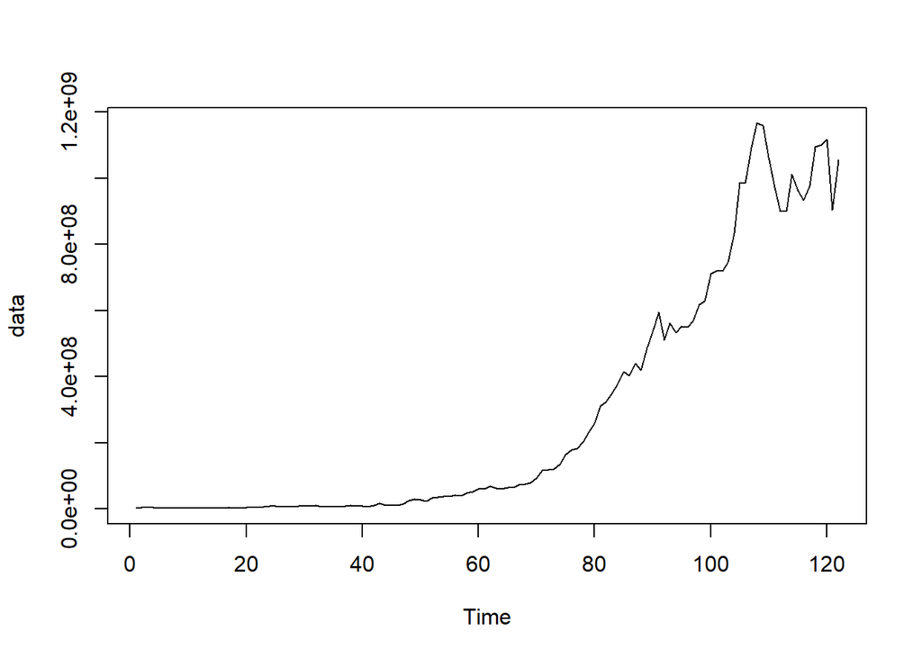

```r
plot(data)
```

S rastúcimi hodnotami rastie disperzia dát, preto dáta zlogaritmujeme:

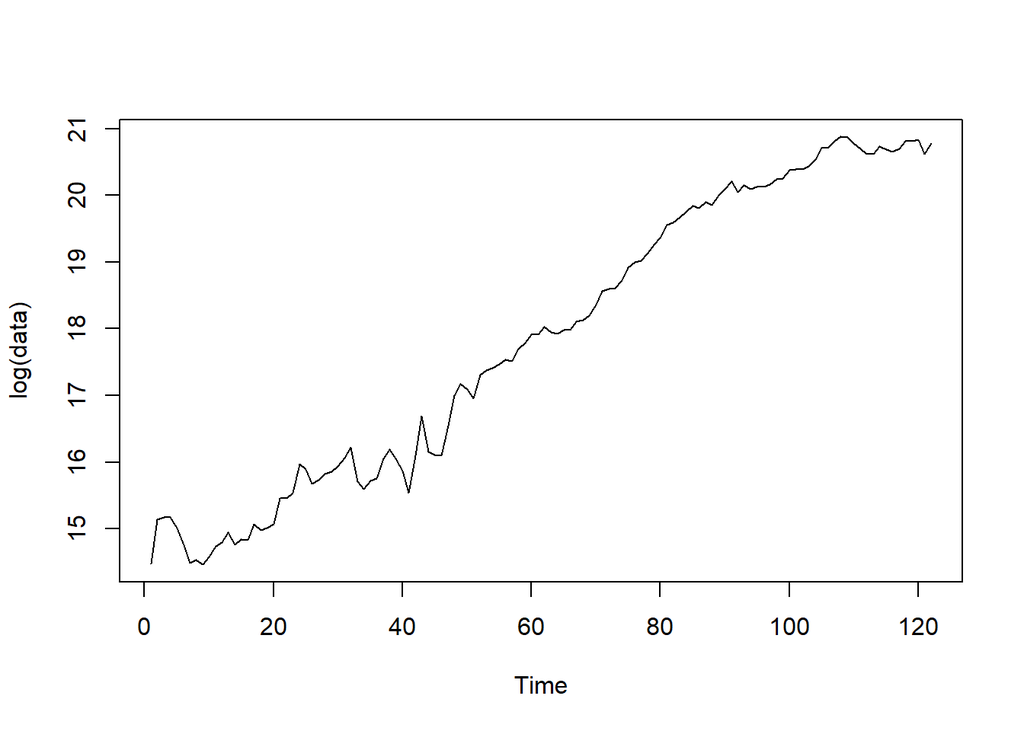

```r
plot(log(data))
```

V týchto dátach je rastúci trend, preto nie sú stacionárne a kvôli tomu ich zdiferencujeme:

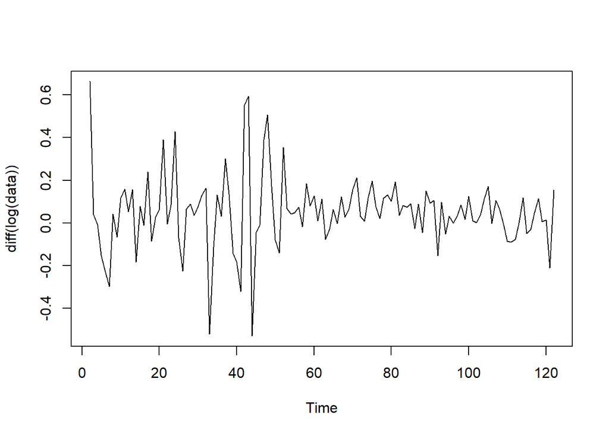

```r
plot(diff(log(data)))
```

Pre tieto dáta budeme testovať AR model, bude však formulovaný ako AR model pre logaritmy. Hľadáme teda model v tvare

```r
sarima(log(data), p, 1, q)
```